**FFT Practice**

By Prof. Seungchul Lee  
http://iai.postech.ac.kr/  
Industrial AI Lab at POSTECH

Table of Contents

# 1. FFT with Sampling Frequency

## 1.1. Implementing FFT routine

```python
import numpy as np
import matplotlib.pyplot as plt
%matplotlib inline

import IPython.display as ipd
import librosa.display
from mpl_toolkits.mplot3d import Axes3D

from scipy import signal
from scipy.fftpack import fft, fftshift
```

You can think this signal as a vibration signal from a rotating machinery with 60 Hz (or 60 $\times$ 60 = 3600 rpm)

```python
Fs = 1000            # Sampling frequency
T = 1/Fs             # Sampling period (or sampling interval)

N = 5000             # Total data points (signal length)

t = np.arange(0, N)*T        # Time vector (time range)

k = np.arange(0, N)          # vector from 0 to N-1
f = (Fs/N)*k         # frequency range
```

```python
x = 2*np.cos(2*np.pi*60*t)
xn = x + 1*np.random.randn(len(x))
```

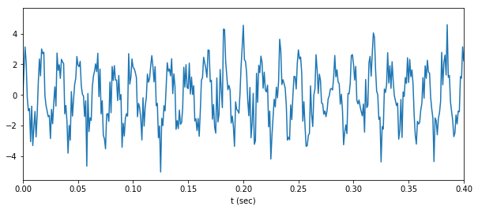

```python
plt.figure(figsize=(10, 4))
plt.plot(t, xn)
plt.xlim([0, 0.4])
plt.xlabel('t (sec)')
plt.show()
```

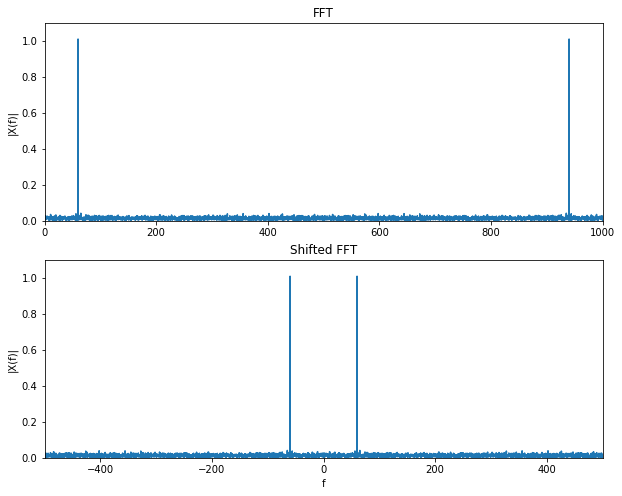

```python
# original fft

xnt = fft(xn)/N
xntshift = fftshift(xnt)

kr = np.hstack([np.arange(0, N/2), np.arange(-N/2, 0)])
fr = (Fs/N)*kr
fs = fftshift(fr)

plt.figure(figsize=(10,8))
plt.subplot(2,1,1)
plt.plot(f, np.abs(xnt))
plt.ylabel('|X(f)|')
plt.ylim([0, 1.1])
plt.xlim([0, 1000])
plt.title('FFT')

plt.subplot(2,1,2)
plt.plot(fs, np.abs(xntshift))
plt.ylim([0, 1.1])
plt.xlim([-500, 500])
plt.xlabel('f')
plt.ylabel('|X(f)|')
plt.title('Shifted FFT')
plt.show()
```

## 1.2. Single-sided FFT (or Positive FFT)

- Only want the first half of the FFT, since the last is redundant (symmetric)
- 2 $\times$ amplitude except the DC component

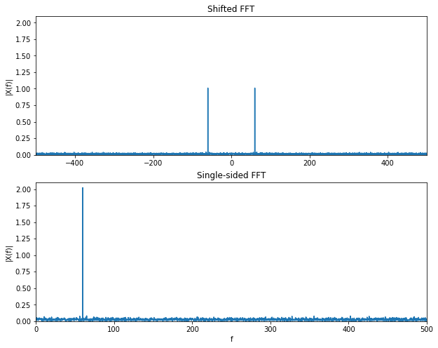

```python
# single-sides fft

xnt = fft(xn)/N
xntss = xnt[0:int(N/2)+1] # 0:N/2
xntss[1:-1] = 2*xntss[1:-1]

fss = f[0:int(N/2)+1]

plt.figure(figsize=(10,8))
plt.subplot(2,1,1)
plt.plot(fs, np.abs(xntshift))
plt.ylabel('|X(f)|')
plt.ylim([0, 2.1])
plt.xlim([np.min(fs), np.max(fs)])
plt.title('Shifted FFT')

plt.subplot(2,1,2)
plt.plot(fss, np.abs(xntss))
plt.xlim([np.min(fss), np.max(fss)])
plt.xlabel('f')
plt.ylabel('|X(f)|')
plt.ylim([0, 2.1])
plt.title('Single-sided FFT')
plt.show()
```

# 2. Extract Amplitude of the Specific Frequency

For instance,

$$X_{\text{feature vector}} = \text{amplitude at } 1X$$

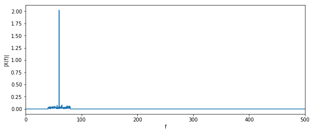

```python
amplitude = np.abs(xntss)

f1 = 60
c = 20

filter01 = np.zeros(amplitude.shape)
filter01[int(N/Fs*(f1-c)):int(N/Fs*(f1+c))] = 1

X1 = np.max(amplitude*filter01)

plt.figure(figsize=(10, 4))
plt.plot(fss, amplitude*filter01)
plt.xlim([np.min(fss), np.max(fss)])
plt.xlabel('f')
plt.ylabel('|X(f)|')
plt.show()
```

# 3. Envelope Analysis

## 3.1. Beats

```python
%%html
<center><iframe src="https://www.youtube.com/embed/7YEyMLX3sD8?rel=0"
width="420" height="315" frameborder="0" allowfullscreen></iframe></center>
```

[video not shown]

$$\cos(2 \pi f_1 t) + \cos(2 \pi f_2 t) = 2 \cos \left(2 \pi \frac{f_1 + f_2}{2} t \right) \cos \left(2 \pi \frac{f_1 - f_2}{2} t \right) $$

```python
Fs = 44100           # Sampling frequency
T = 1/Fs             # Sampling period (or sampling interval)

N = 5*Fs             # Total data points (signal length)

t = np.arange(0, N)*T        # Time vector (time range)

k = np.arange(0, N)          # vector from 0 to N-1
f = (Fs/N)*k         # frequency range
```

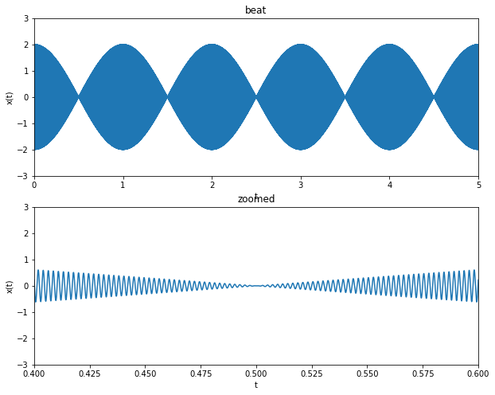

```python
x = np.cos(2*np.pi*440*t) + np.cos(2*np.pi*441*t)

plt.figure(figsize=(10,8))
plt.subplot(2,1,1)
plt.plot(t, x)
plt.xlabel('t')
plt.ylabel('x(t)')
plt.ylim([-3, 3])
plt.xlim([np.min(t), np.max(t)])
plt.title('beat')

plt.subplot(2,1,2)
plt.plot(t, x)
plt.xlim([0.4, 0.6])
plt.ylim([-3, 3])
plt.xlabel('t')
plt.ylabel('x(t)')
plt.title('zoomed')
plt.show()
```

```python
ipd.Audio(x.T, rate=Fs)
```

[interactive chart not shown]

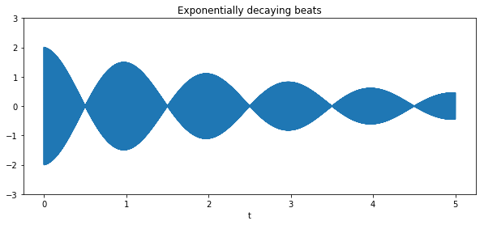

```python
# plot -s 560,250

xexp = x*np.exp(-0.3*t)

plt.figure(figsize=(10, 4))
plt.plot(t, xexp)
plt.xlabel('t')
plt.title('Exponentially decaying beats')
plt.ylim([-3, 3])
plt.show()
```

```python
ipd.Audio(xexp.T, rate=Fs)
```

[interactive chart not shown]

## 3.2. Modulation and Demodulation

Modulation is the process of varying one or more properties of a periodic waveform, called the carrier signal, with a modulating signal that typically contains information to be transmitted. Most radio systems in the 20th century used frequency modulation (FM) or amplitude modulation (AM) to make the carrier carry the radio broadcast.

[figure not shown]

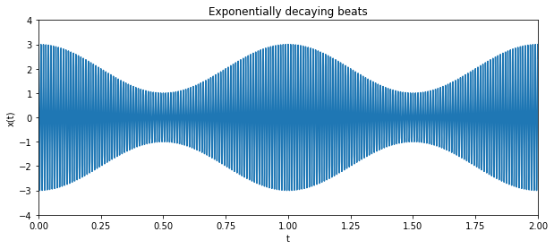

```python
Fs = 1000            # Sampling frequency
T = 1/Fs             # Sampling period (or sampling interval)

N = 5*Fs             # Total data points (signal length)

t = np.arange(0, N)*T        # Time vector (time range)

k = np.arange(0, N)          # vector from 0 to N-1
f = (Fs/N)*k         # frequency range

sig = np.cos(2*np.pi*1*t) + 2
carrier = np.cos(2*np.pi*100*t)

x = sig*carrier

plt.figure(figsize=(10, 4))
plt.plot(t, x)
plt.xlabel('t')
plt.ylabel('x(t)')
plt.title('Exponentially decaying beats')
plt.ylim([-4, 4])
plt.xlim([0, 2])
plt.show()
```

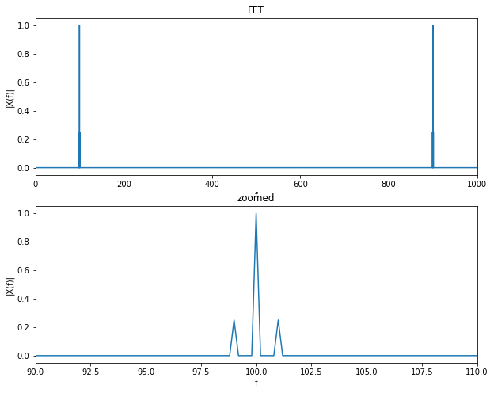

```python
xt = fft(x)/N

plt.figure(figsize=(10,8))
plt.subplot(2,1,1)
plt.plot(f, np.abs(xt))
plt.xlabel('f')
plt.ylabel('|X(f)|')
plt.xlim([np.min(f), np.max(f)])
plt.title('FFT')

plt.subplot(2,1,2)
plt.plot(f, np.abs(xt))
plt.xlim([90, 110])
plt.xlabel('f')
plt.ylabel('|X(f)|')
plt.title('zoomed')
plt.show()
```

Hilbert Transform

- Do not worry about the equation. It will give us the envelope of a signal

$$H(u(t)) = \frac{1}{\pi} \int_{-\infty}^{\infty} \frac{u(\tau)}{t-\tau} d\tau$$

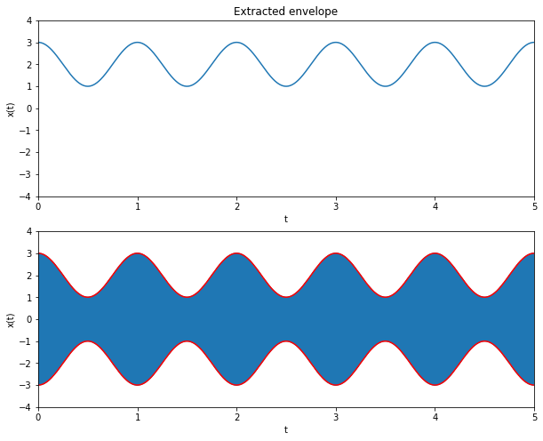

```python
# extract envelope using Hilbert transform

xe = np.abs(signal.hilbert(x))

plt.figure(figsize=(10,8))
plt.subplot(2,1,1)
plt.plot(t, xe)
plt.xlabel('t')
plt.ylabel('x(t)')
plt.ylim([-4, 4])
plt.xlim([np.min(t), np.max(t)])
plt.title('Extracted envelope')

plt.subplot(2,1,2)
plt.plot(t, x)
plt.plot(t, -xe, 'r-')
plt.plot(t, xe, 'r-')
plt.xlim([np.min(t), np.max(t)])
plt.ylim([-4, 4])
plt.xlabel('t')
plt.ylabel('x(t)')
plt.show()
```

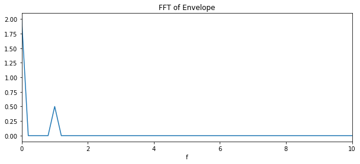

```python
xet = fft(xe)/N

plt.figure(figsize=(10, 4))
plt.plot(f, np.abs(xet))
plt.xlabel('f')
plt.title('FFT of Envelope')
plt.xlim([0, 10])
plt.show()
```

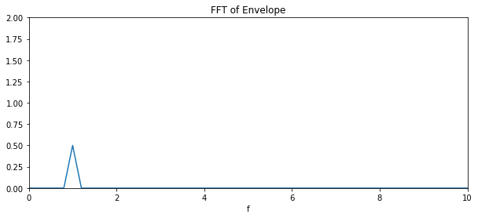

```python
xez = xe - np.mean(xe) # remove dc offset
xezt = fft(xez)/N

plt.figure(figsize=(10, 4))
plt.plot(f, np.abs(xezt))
plt.xlabel('f')
plt.title('FFT of Envelope')
plt.xlim([0, 10])
plt.ylim([0, 2])
plt.show()
```

# 4. STFT (Short-Time Fourier Transform)

```python
Fs = 2**10           # Sampling frequency
T = 1/Fs             # Sampling period (or sampling interval)

N = 2*Fs             # Total data points (signal length)

t = np.arange(0, N)*T        # Time vector (time range)

k = np.arange(0, N)          # vector from 0 to N-1
f = (Fs/N)*k         # frequency range

x1 = np.cos(2*np.pi*50*t)
x2 = np.cos(2*np.pi*100*t)

x = np.zeros(t.shape)
x[0:int(N/2)] = x1[0:int(N/2)]
x[int(N/2):-1] = x2[int(N/2):-1]
```

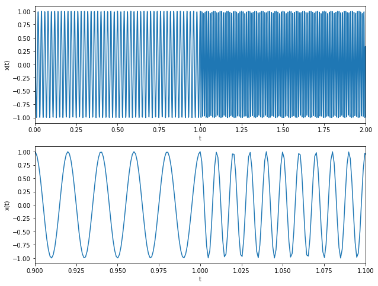

```python
plt.figure(figsize=(10,8))
plt.subplot(2,1,1)
plt.plot(t, x)
plt.xlabel('t')
plt.ylabel('x(t)')
plt.xlim([np.min(t), np.max(t)])

plt.subplot(2,1,2)
plt.plot(t, x)
plt.xlim([0.9, 1.1])
plt.xlabel('t')
plt.ylabel('x(t)')
plt.show()
```

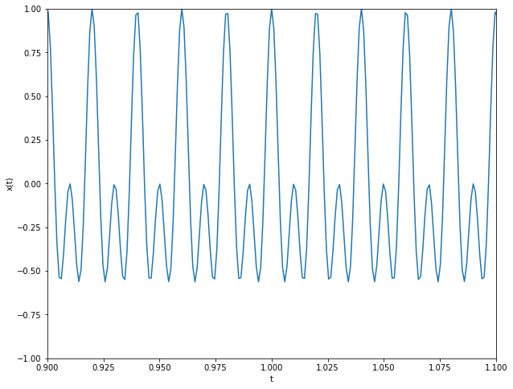

```python
z = 1/2*(x1 + x2)

plt.figure(figsize=(10,8))
plt.plot(t, z)
plt.xlabel('t')
plt.ylabel('x(t)')
plt.xlim([0.9,1.1])
plt.ylim([-1,1])

plt.show()
```

FFT does not provide time information of the signal.

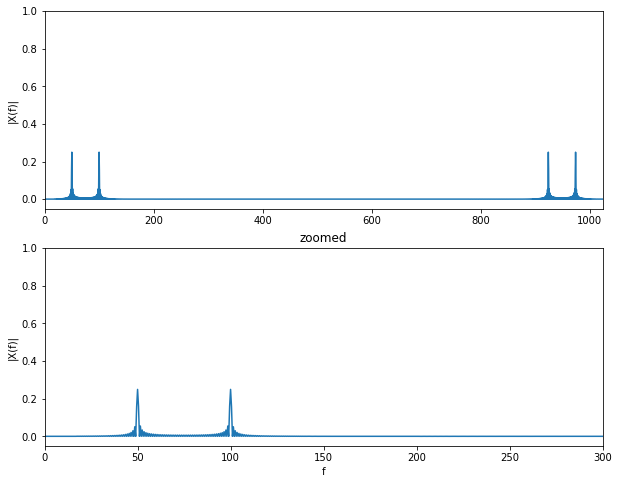

```python
xt = fft(x)/N

plt.figure(figsize=(10,8))
plt.subplot(2,1,1)
plt.plot(f, np.abs(xt))
plt.ylim([-0.05,1])
plt.ylabel('|X(f)|')
plt.xlim([np.min(f), np.max(f)])

plt.subplot(2,1,2)
plt.plot(f, np.abs(xt))
plt.xlim([0, 300])
plt.ylim([-0.05,1])
plt.xlabel('f')
plt.ylabel('|X(f)|')
plt.title('zoomed')
plt.show()
```

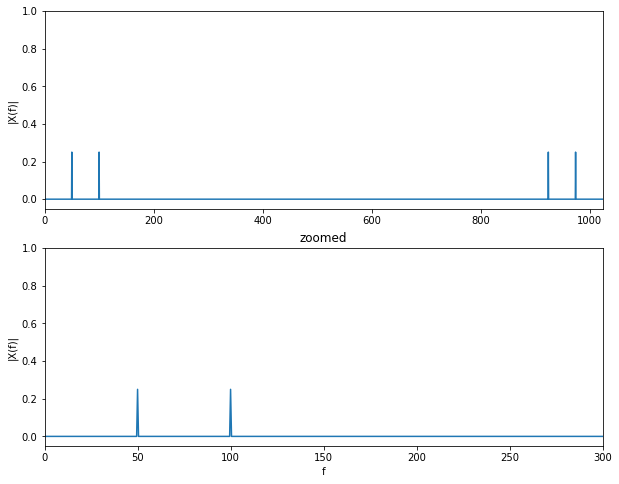

```python
zt = fft(z)/N

plt.figure(figsize=(10,8))
plt.subplot(2,1,1)
plt.plot(f, np.abs(zt))
plt.ylim([-0.05,1])
plt.ylabel('|X(f)|')
plt.xlim([np.min(f), np.max(f)])

plt.subplot(2,1,2)
plt.plot(f, np.abs(zt))
plt.xlim([0, 300])
plt.ylim([-0.05,1])
plt.xlabel('f')
plt.ylabel('|X(f)|')
plt.title('zoomed')
plt.show()
```

- The spectral content of speech changes over time (non-stationary)
  - As an example, formants change as a function of the spoken phonemes
  - Applying the DFT over a long window does not reveal transitions in spectral content
- To avoid this issue, we apply the DFT over short periods of time
  - For short enough windows, speech can be considered to be stationary
  - Remember, though, that there is a time-frequency tradeoff here!

[figure not shown]

```python
import scipy

windowsize = 2**7
window = np.hanning(windowsize)
nfft = windowsize
noverlap = windowsize/2
```

```python
def stft(signal, Fs, frame_size, hop):

    frame_sample = int(frame_size * Fs)
    hop_sample = int(hop * Fs)

    W = scipy.hanning(frame_sample)
    X = scipy.array([scipy.fft(W*signal[i:i+frame_sample]) for i in range(0, len(signal) - frame_sample, hop_sample)])

    return X.T
```

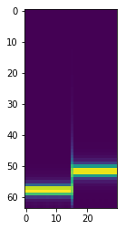

```python
X = stft(x, Fs,1/8, 1/16)

plt.imshow(np.log(1+np.abs(X))[X.shape[0]//2:,])

plt.show()
```

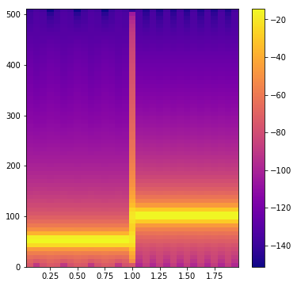

```python
fig = plt.figure(figsize=(6,6))
ax = fig.add_subplot(1,1,1)
s, f, t, im = ax.specgram(x, NFFT = nfft, Fs = Fs, window = window, cmap='plasma', noverlap = noverlap, mode='psd', scale='dB')
plt.colorbar(im)
plt.show()
```

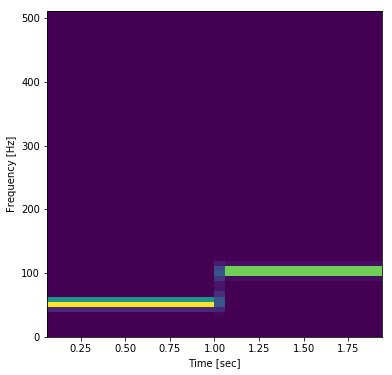

```python
from scipy.signal import spectrogram

f, t, Sxx = spectrogram(x, Fs, window=window, noverlap=noverlap, nfft=nfft, scaling='spectrum', mode='psd')
plt.figure(figsize=(6, 6))
plt.pcolormesh(t, f, Sxx)
plt.ylabel('Frequency [Hz]')
plt.xlabel('Time [sec]')
plt.show()
```

```python
%%javascript
$.getScript('https://kmahelona.github.io/ipython_notebook_goodies/ipython_notebook_toc.js')
```